# Лабораторная работа №11

Операционные системы

Верниковская Е. А., НПИбд-01-23

Российский университет дружбы народов, Москва, Россия

18 апреля 2024

# Вводная часть

## Цель работы

Познакомиться с операционной системой Linux. Получить практические навыки работы с редактором Emacs.

## Задание

1. Ознакомиться с теоретическим материалом.
2. Ознакомиться с редактором emacs.
3. Выполнить упражнения.
4. Ответить на контрольные вопросы.

# Выполнение лабораторной работы

## Выполнение лабораторной работы

Скачиваем emacs (рис. 1)

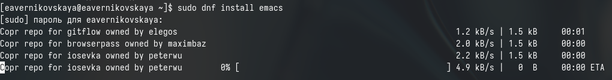

Установка emacs

## Выполнение лабораторной работы

Открываем emacs (рис. 2), (рис. 3)

## Выполнение лабораторной работы

[figure not shown]

Главное меню emacs

## Выполнение лабораторной работы

Создаём файл lab10.sh с помощью комбинации Ctrl-x и Ctrl-f (рис. 4), (рис. 5)

## Выполнение лабораторной работы

[figure not shown]

Открытие файла

## Выполнение лабораторной работы

Вводим нужный текст: (рис. 6)

[output not shown]

## Выполнение лабораторной работы

[figure not shown]

Введённый текст

## Выполнение лабораторной работы

Вырезаем одной командой целую строку (С-k) (рис. 8)

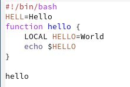

Вырезание строки

## Выполнение лабораторной работы

Вставляем эту строку в конец файла (C-y) (рис. 9)

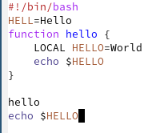

Вставка вырезанной строки

## Выполнение лабораторной работы

Выделяем область текста (C-space) (рис. 10)

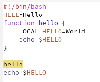

Выделение области текста

## Выполнение лабораторной работы

Копируем область в буфер обмена (M-w) и вставляем область в конец файла (рис. 11)

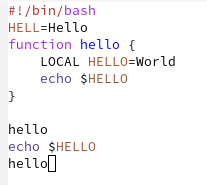

Копирование области текста и её вставка

## Выполнение лабораторной работы

Вновь выделяем эту область и на этот раз вырезаем её (C-w) (рис. 12)

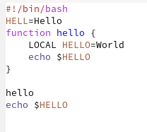

Вырезание выделенной области

## Выполнение лабораторной работы

Отменяем последнее действие (C-/) (рис. 13)

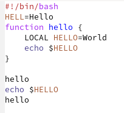

Отмена последих действий

## Выполнение лабораторной работы

Перемещаем курсор в начало строки (C-a) (рис. 14)

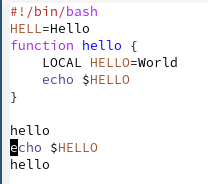

Курсор в начало строки

## Выполнение лабораторной работы

Перемещаем курсор в конец строки (C-e) (рис. 15)

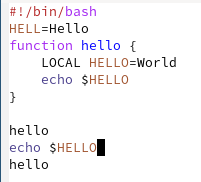

Курсор в конец строки

## Выполнение лабораторной работы

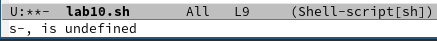

## Выполнение лабораторной работы

Выводим список активных буферов на экран (C-x C-b) (рис. 18)

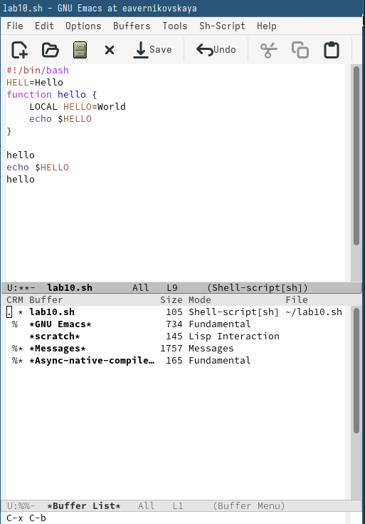

Список активных буферов

## Выполнение лабораторной работы

Перемещаемся во вновь открытое окно (C-x) со списком открытых буферов и переключитесь на другой буфер (рис. 19)

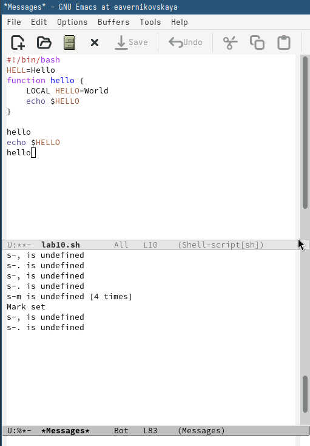

Переключение на другой буфер

## Выполнение лабораторной работы

Закрываем это окно (C-x 0) (рис. 20)

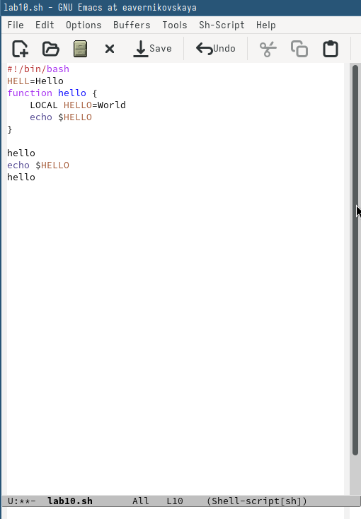

Закрытие окна

## Выполнение лабораторной работы

Далее делим фрейм на 4 части: делим сначала фрейм на два окна по вертикали (C-x 3), а затем каждое из этих окон на две части по горизонтали (C-x 2) (рис. 22), (рис. 23)

## Выполнение лабораторной работы

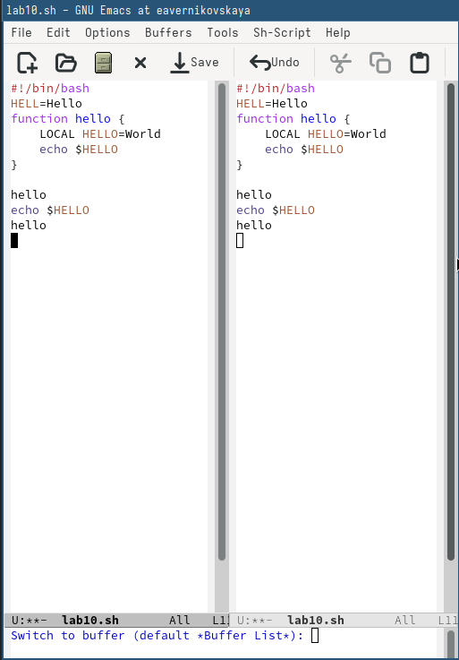

Деление по вертикали

## Выполнение лабораторной работы

[figure not shown]

Деление по горизонтали

## Выполнение лабораторной работы

После переключаемся в режим поиска (C-s) и находим несколько слов, присутствующих в тексте (рис. 24), (рис. 25)

## Выполнение лабораторной работы

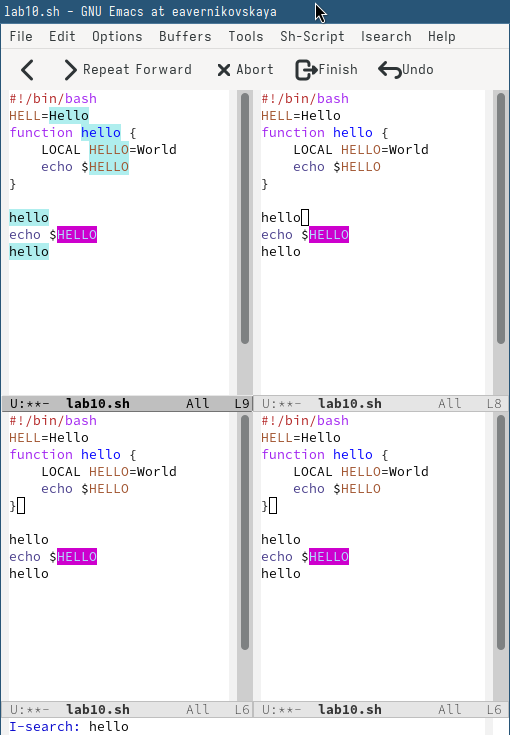

Результаты поиска

## Выполнение лабораторной работы

Переходим в режим поиска и замены (M-%), вводим текст, который следует найти и заменить, нажимаем Enter, затем вводим текст для замены. После того как будут подсвечены результаты поиска, нажимаем ! для подтверждения замены. Но перед этим всем мы переходим в режим начала буфера (рис. 27), (рис. 28), (рис. 29)

## Выполнение лабораторной работы

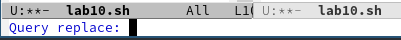

Режим поиска и замены

## Выполнение лабораторной работы

[figure not shown]

Процесс замены словам

## Выполнение лабораторной работы

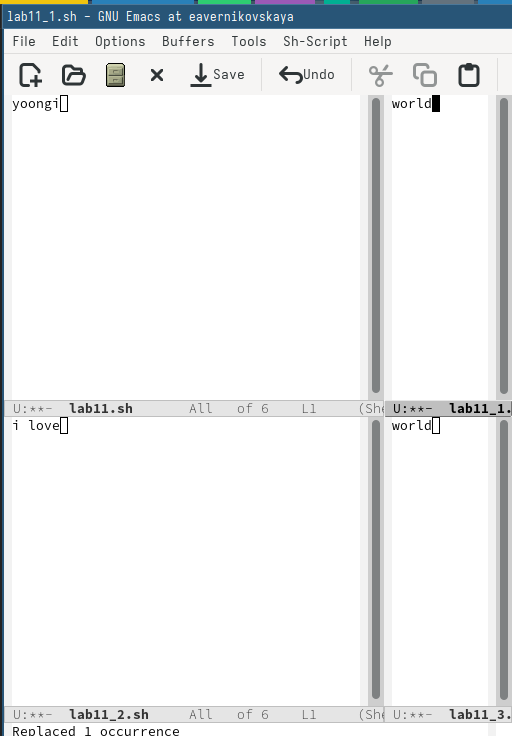

Замена слова

## Выполнение лабораторной работы

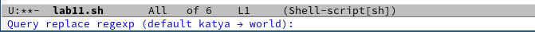

Режим regexp

# Подведение итогов

## Выводы

В ходе выполнения лабораторной работы мы ознакомились с операционной системой Linux а также получили практические навыки работы с редактором Emacs.

## Список литературы

Не пользовалась сайтами.